# The differences between Trump and Biden voters and their view on key issues

## Introduction

The 2020 election was a tight race between Republican nominee President Donald Trump and Democratic nominee former Vice President Joe Biden. Trump won the 2016 presidential election with a majority of the Electoral College victory over Hillary Clinton but Clinton won the popular vote by nearly three percent. With the current COVID-19 pandemic, the election system has changed to accommodate the difficult circumstances with increasing mail-in ballots, early voting, vitual campaigns, etc. The election was held on November 3 and Joe Biden was elected as the 46th Pkresident of United States desipte Trump’s effort to overturn the election with voter fraud claims that has no edvidence to support his allegations.

The dataset used in the following study is provided by the American National Election Studies(ANES) 2020 Exploratory Testing Survey conducted between April 10, 2020 and April 18, 2020. The dataset included responses from 3,080 adult citizens across the United States with 470 variable of questions regarding changes in the political environment and recent developments in social science research. The following analysis will focus on identifying the differences between Trump and Biden voters and their view on key issues to better picture what might cause Trump’s loss.

## Exploration Data Analysis

### Survey participants vote distribution

We first want to understand the distribution of the survey participants on who they voted for in the 2020 elections. The distribution shows that 43% of the participants voted for Biden while 40.8% voted for Trump. Looking back into the 2016 election, 37.5% of participants voted for Trump and 35.6% voted for Clinton while 21.3% did not vote.

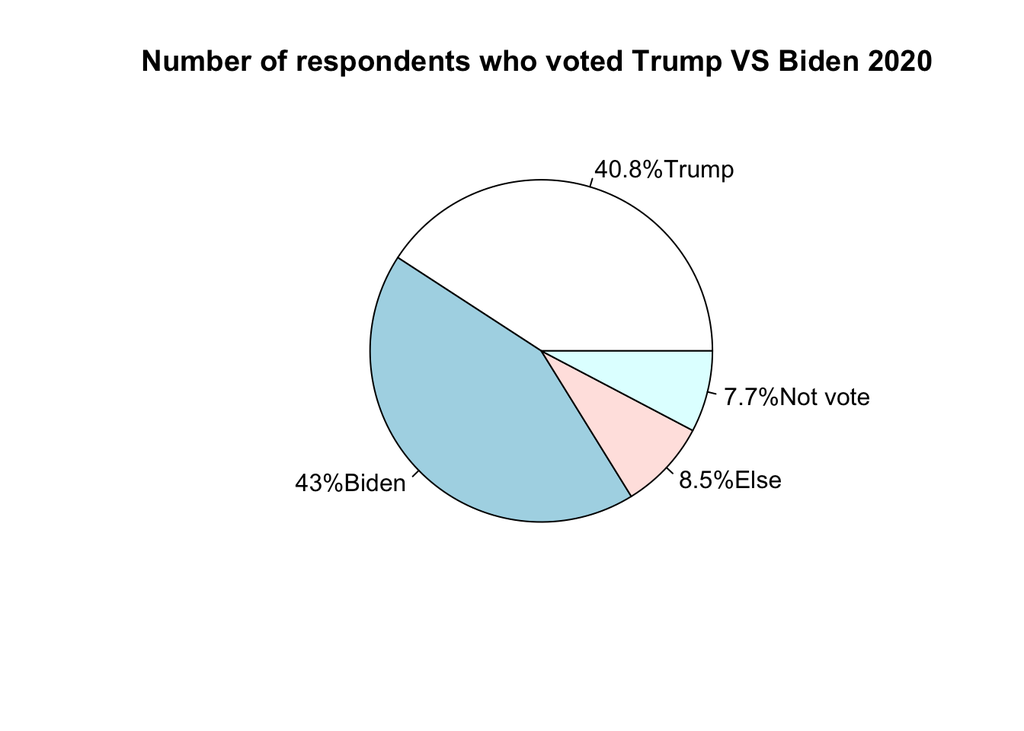

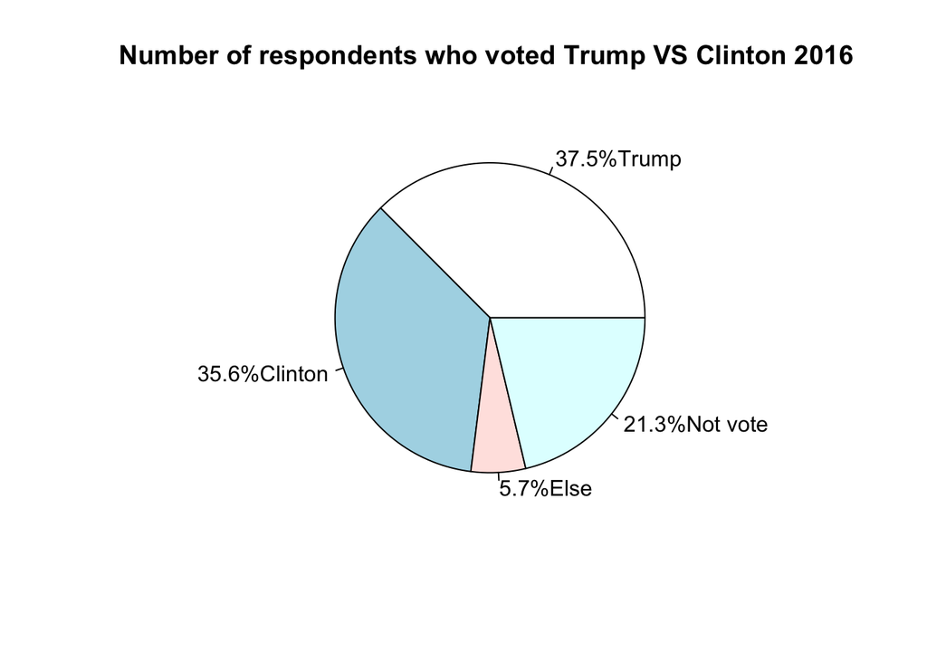

For the participants who voted for Trump in 2016, 87.9% of them kept their choice and voted for Trump in 2020 while 7.8% changed their vote to Biden. For the participants who voted for Clinton in 2016, 87.5% of them voted for Biden in 2020 while 3.8% changed their vote to Trump. The number of people who did not vote in 2016 drop from 21.3% to 7.7% in 2020. Among those who decided to vote in 2020, 33.1% voted for Biden while 27% voted for Trump.

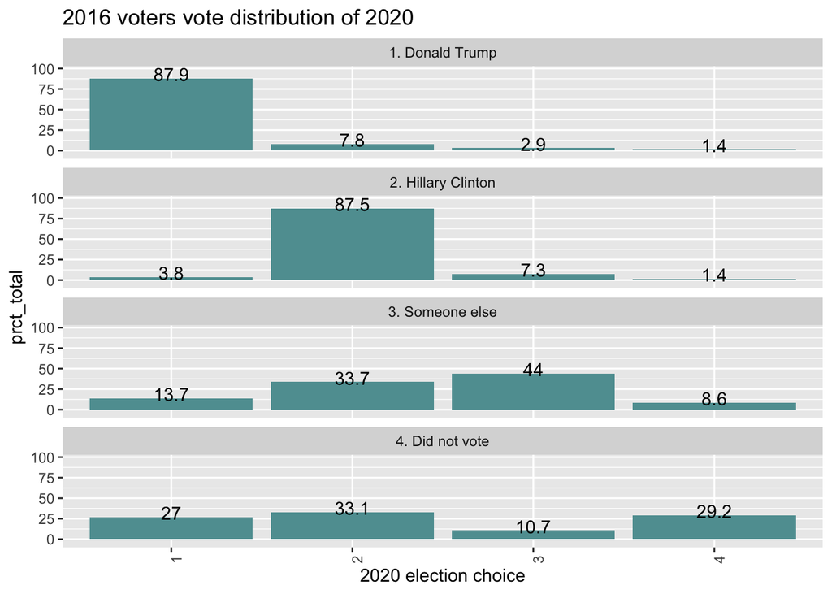

### Demographics

Biden has more female voters while Trump has more male voters.

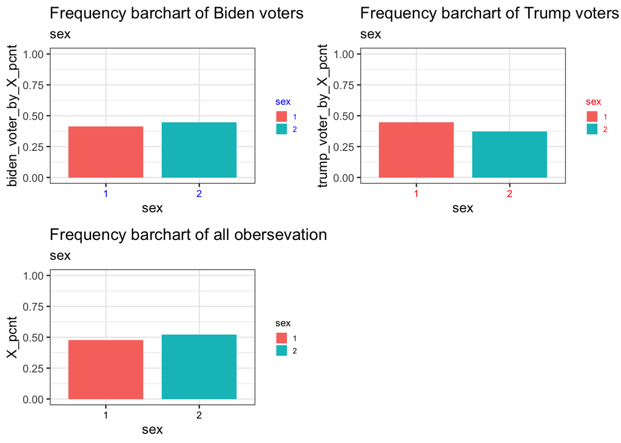

Biden has more voters with higher education than Bachelor’s degree while Trump has more voters with lower education.

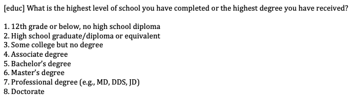

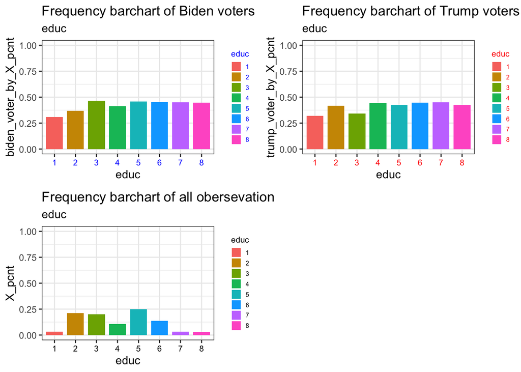

Biden’s voters have lower total household income than Trump’s voters.

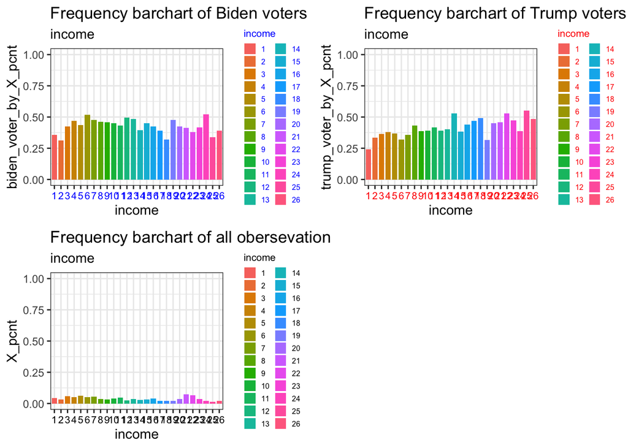

Most Biden’s voters are Democrat and most Trump’s voters are Republican but there is a higher percentage of Democrat voters voted for Trump than Republican voted for Biden. More independent voters voted for Biden than Trump.

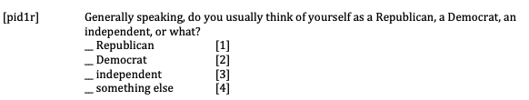

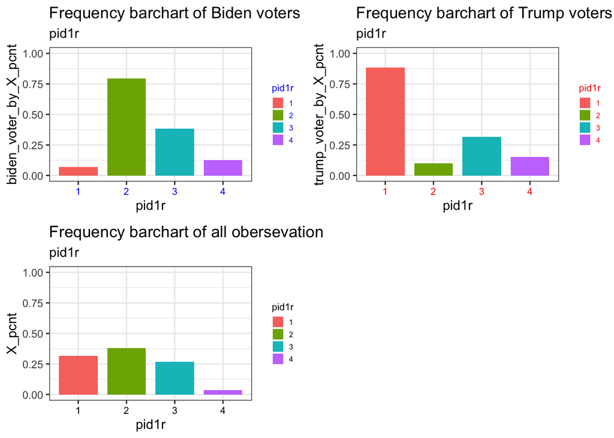

## Views on election accuracy and mail-in ballots

Overall, most voters believed that the 2020 election is accurate with higher percentage of Trump voters thinking the election results is completely accurate. However, the two group of voters have very different view on the accuracy of mail-in ballots. Biden’s voter tend to support mail in ballots and strongly trusting the accuracy of voting by mail while Trump’s vote tend to not support the mail in ballots and not at all believe in the accuracy of voting by mail. The strong disbelieve in mail in ballots has led Trump’s vote to post election protest and supporting Trump’s claim that the election was fraudulent.

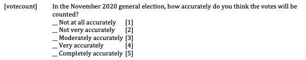

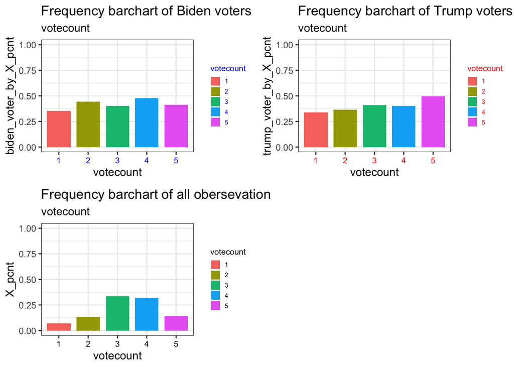

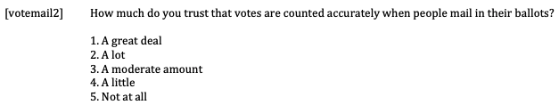

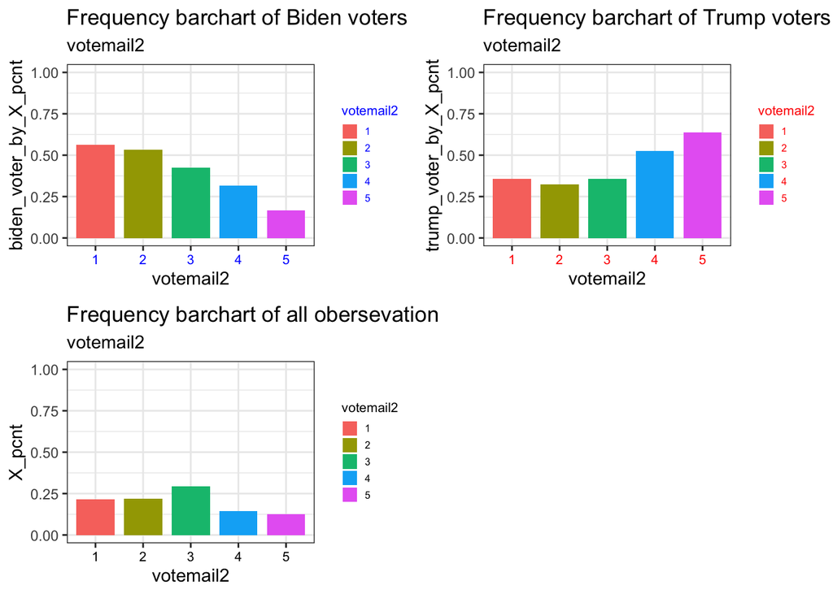

## Views on Trump’s policies:

The two groups of voters have extreme views on the way Trump handles his job as president with Biden’s voters mostly disapprove strongly while Trump’s voters approved strongly. The vote responses on relations with foreign countries, immigration policies, economic policies, COVID response and health care policies all follow the same trend with extreme views from the two group of voters. However, there are more Biden’s voters who approval Trump’s economic policies over other issues.

```
## [1] "Overall Trump's job approval"
```

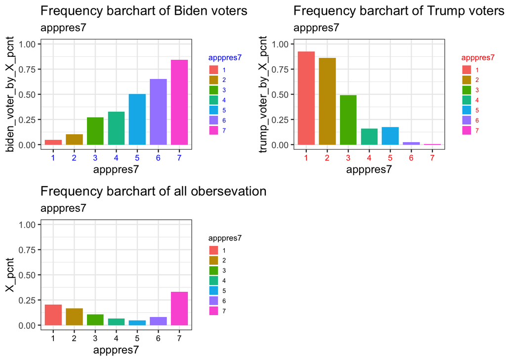

```
## [1] "Approval on Trump's relations with foreign countries"
```

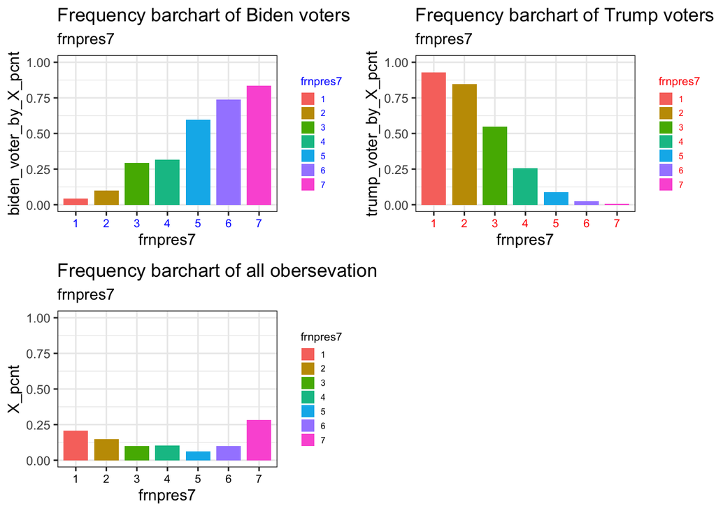

```
## [1] "Approval on Trump's immigration policies"
```

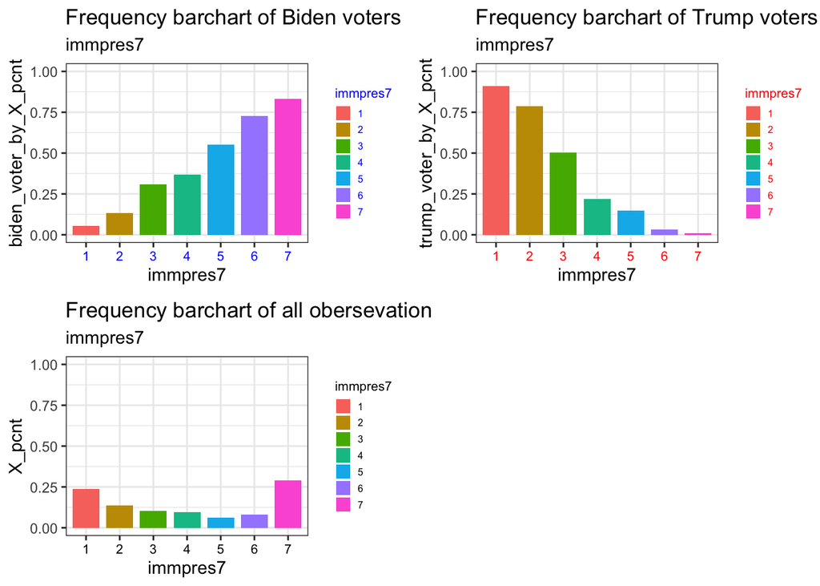

```
## [1] "Approval on Trump's economic policies"
```

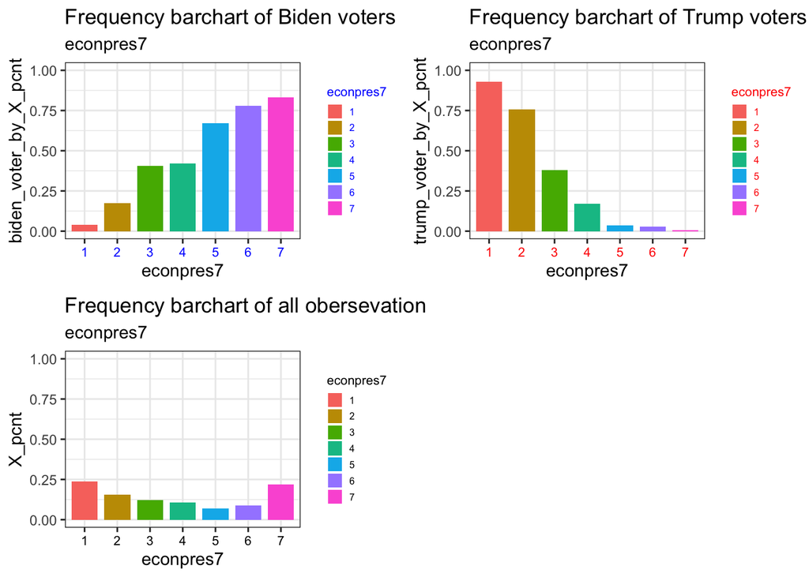

```
## [1] "Approval on Trump's COVID response"
```

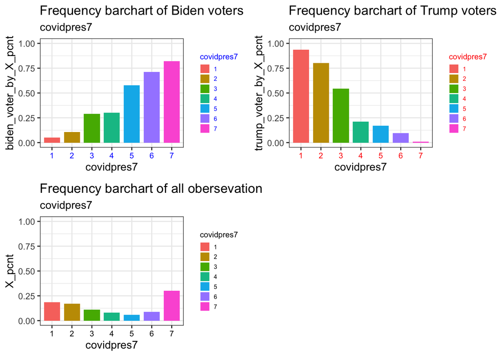

```
## [1] "Approval on Trump's health care policies"
```

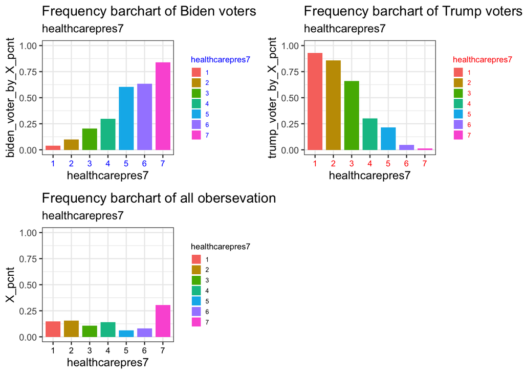

## Voter view on key issues:

### COVID-19:

Overall, voters are somewhat worried about getting COVID but extremely worried about the upcoming economic impact. Most Trump’s voters were not worried about catching COVID-19 but were moderately concern about the economic impact of the coronavirus while most Biden’s voters were worried about getting COVID and extremely worried about the economic impact.

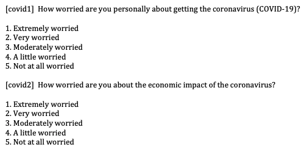

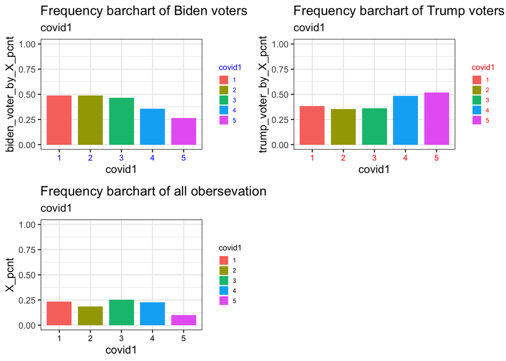

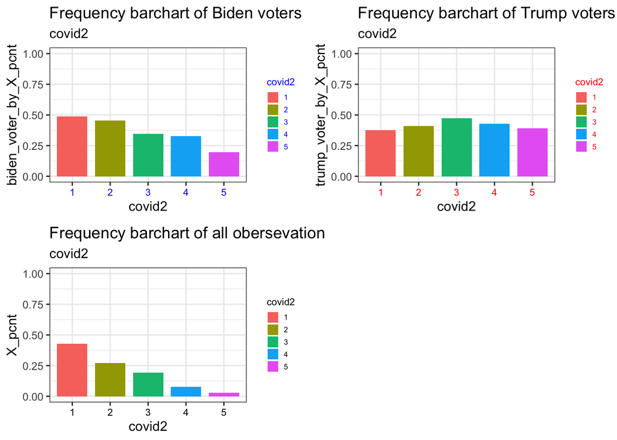

### Abortion:

Trump’s voters are against abortion and sugguest that abortion right should be tighten with laws while Biden’s voters mostly believe that woman should always have abortion right and some support tightening abortion laws.

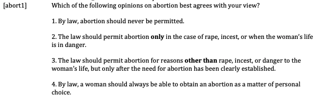

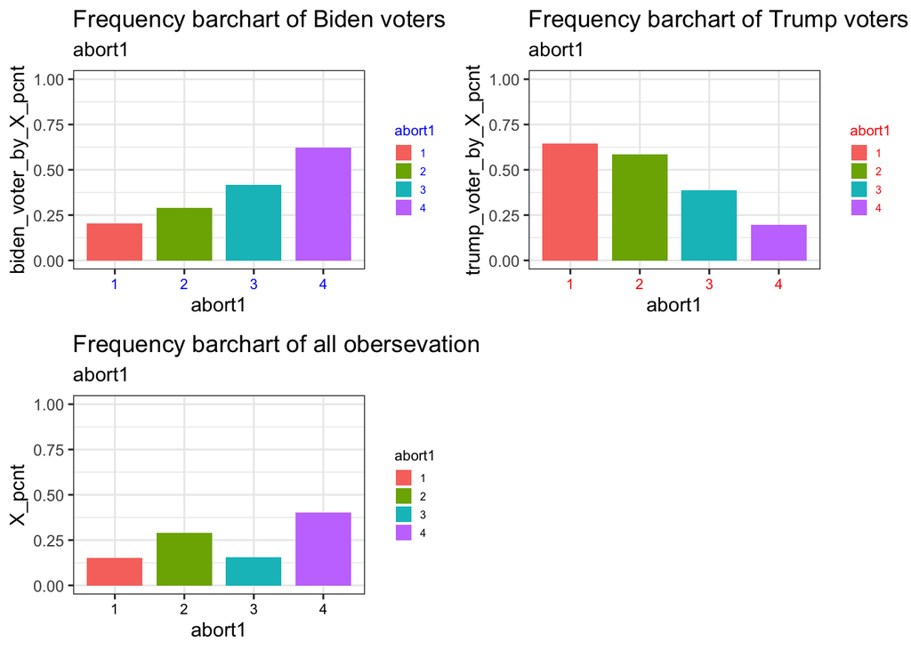

### MeToo Movement:

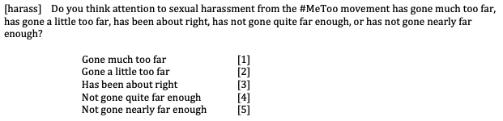

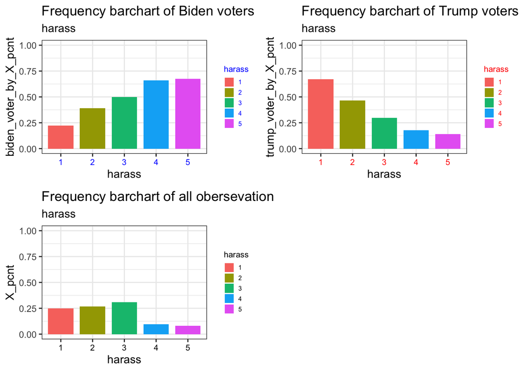

## Conclusion:

In conclusion, Biden has more female voters while Trump has more male voters, Biden has more voters with higher education than Trump but their overall total household is lower than Trump’s voters. Most Biden’s voters are Democrat and most Trump’s voters are Republican but there is a higher percentage of Democrat voters who voted for Trump than Republican voted for Biden.

The two groups of voters have different views on the accuracy of voting by mail as Trump’s voters strongly disbelieve in the accuracy of voting by mail. They also have extreme views on the way Trump handles his job as president as you can see the graphs are following the same trends with Biden’s voters mostly disapprove of all Trump’s policies while Trump’s voters approve them strongly. However, there are more Biden’s voters who approval Trump’s economic policies over other issues.

All voters are somewhat worried about getting COVID. Most Trump’s voters are not extremely worried about the economic impact as they tend to have higher HH incomes while Biden’s voters are more concerned.

Finally, the view points on key issue follows similar trends as Biden’s voter are more liberal as most of them are Democrat supporting Abortion rights and MeToo movement while Trump voters are more convervation and have opposite stands. Also, there are more female Biden supporters which might also increase their support for these issues.